# **Projeto I**

**Consumo de frutas na pandemia de COVID-19**

Olga Grichtchouk (ogrichtchouk@id.uff.br)

Universidade Federal Fluminense

20/10/2026

## Introdução

- **Contextualização:**

[figure not shown]

## Objetivos

- Avaliar a associação entre características sociodemográficas, econômicas, antropométricas e comportamentais na **mudança de consumo de frutas** no contexto da pandemia de COVID-19.
- Explorar, de forma integrada, possíveis fatores associados às alterações de hábitos alimentares e comportamentais observadas durante a pandemia.

## Metodologia

- **Questionário:** 2155 respostas coletadas de forma online por alunas de pós-graduação da Nutrição da UFF, em 2022.
- **Variável resposta:** Mudança no consumo de frutas (Aumentou, Diminuiu, Não alterou).
- **Variáveis categóricas:** Gênero, Raça/Cor, Região, Isolamento, Situação de trabalho, Renda familiar, Escolaridade, Diagnóstico de COVID-19, Consulta com nutricionista, Dificuldade financeira, Hábito de fumar, Ansiedade, Depressão, Insônia, e Enxaqueca.
- **Variáveis quantitativas:** Idade, Peso, Altura, e IMC.

## Metodologia

- **Análises das variáveis categóricas:** teste qui-quadrado de independência ou teste exato de Fisher (<5).
- **Análises das variáveis quantitativas:** Análise da normalidade e homogeneidade das variâncias. ANOVA Clássica ou ANOVA de Welch. Teste post-hoc: Games-Howell.
- Significância estatística com p< 0,05.

## Resultados

- **Variáveis Categóricas**

| **Variáveis** | **Consumo de frutas** **Aumentou** 918 (43%) | **Consumo de frutas** **Diminuiu** 439 (20%) | **Consumo de frutas** **Não alterou** 798 (37%) | **Valor-p** | **Cramér** |  |  |
| --- | --- | --- | --- | --- | --- | --- | --- |
| Gênero<sup>F</sup> |  |  |  |  |  | 0,239 | 0,044 |
| Feminino | 684 (43%) | 341 (21%) | 577 (36%) |  |  |  |  |
| Masculino | 228 (42%) | 96 (18%) | 218 (40%) |  |  |  |  |
| Outro | 2 (33%) | 2 (33%) | 2 (33%) |  |  |  |  |
| Prefiro não responder | 4 (80%) | 0 (0%) | 1 (20%) |  |  |  |  |
| Raça/cor<sup>F</sup> |  |  |  | 0,009 | 0,078 |  |  |
| Amarela | 13 (52%) | 4 (16%) | 8 (32%) |  |  |  |  |
| Branca | 552 (41%) | 254 (19%) | 540 (40%) |  |  |  |  |
| Indígena | 4 (44%) | 3 (33%) | 2 (22%) |  |  |  |  |
| Parda | 260 (45%) | 121 (21%) | 195 (34%) |  |  |  |  |
| Preta | 74 (45%) | 50 (30%) | 42 (25%) |  |  |  |  |
| Outro | 3 (60%) | 0 (0%) | 2 (40%) |  |  |  |  |
| Prefiro não declarar | 12 (43%) | 7 (25%) | 9 (32%) |  |  |  |  |
| Região<sup>Q</sup> |  |  |  | 0,646 | 0,037 |  |  |
| Norte | 143 (47%) | 63 (21%) | 99 (32%) |  |  |  |  |
| Nordeste | 117 (44%) | 58 (22%) | 93 (35%) |  |  |  |  |
| Centro-oeste | 92 (42%) | 38 (18%) | 87 (40%) |  |  |  |  |
| Sudeste | 374 (41%) | 186 (21%) | 347 (38%) |  |  |  |  |
| Sul | 192 (42%) | 94 (21%) | 172 (38%) |  |  |  |  |
| Isolamento<sup>Q</sup> |  |  |  | 0,025 | 0,058 |  |  |
| Não | 394 (41%) | 177 (19%) | 381 (40%) |  |  |  |  |
| Sim | 524 (44%) | 262 (22%) | 417 (35%) |  |  |  |  |
| Trabalha<sup>Q</sup> |  |  |  | 0,006 | 0,069 |  |  |
| Não | 232 (41%) | 143 (25%) | 197 (34%) |  |  |  |  |
| Sim | 686 (43%) | 296 (19%) | 601 (38%) |  |  |  |  |
| Renda familiar<sup>Q</sup> |  |  |  | <0,001 | 0,119 |  |  |
| até R$ 1254,00 | 84 (34%) | 87 (36%) | 74 (30%) |  |  |  |  |
| entre R$ 1.255 - R$ 8.640 | 513 (42%) | 266 (22%) | 451 (37%) |  |  |  |  |
| mais de R$ 8.640 | 321 (47%) | 86 (13%) | 273 (40%) |  |  |  |  |
| Escolaridade<sup>F</sup> |  |  |  | <0,001 | 0,092 |  |  |
| Analfabeto | 1 (50%) | 0 (0%) | 1 (50%) |  |  |  |  |
| Ensino Fundamental Completo | 0 (0%) | 1 (25%) | 3 (75%) |  |  |  |  |
| Ensino Médio Completo | 285 (38%) | 196 (26%) | 261 (35%) |  |  |  |  |
| Ensino Superior Completo | 173 (42%) | 88 (21%) | 155 (37%) |  |  |  |  |
| Pós-graduação | 451 (46%) | 152 (16%) | 371 (38%) |  |  |  |  |
| Não desejo informar | 8 (47%) | 2 (12%) | 7 (41%) |  |  |  |  |
| COVID-19<sup>Q</sup> |  |  |  | 0,886 | 0,011 |  |  |
| Não | 666 (42%) | 319 (20%) | 587 (37%) |  |  |  |  |
| Sim | 252 (43%) | 120 (21%) | 211 (36%) |  |  |  |  |
| Consulta com nutricionista<sup>Q</sup> |  |  |  | <0,001 | 0,090 |  |  |
| Não | 708 (41%) | 376 (22%) | 663 (38%) |  |  |  |  |
| Sim | 210 (51%) | 63 (15%) | 135 (33%) |  |  |  |  |
| Dificuldade financeira<sup>Q</sup> |  |  |  | <0,001 | 0,249 |  |  |
| Não | 775 (44%) | 277 (16%) | 709 (40%) |  |  |  |  |
| Sim | 143 (36%) | 162 (41%) | 89 (23%) |  |  |  |  |
| Cigarro<sup>Q</sup> |  |  |  | 0,055 | 0,052 |  |  |
| Não | 877 (43%) | 408 (20%) | 765 (37%) |  |  |  |  |
| Sim | 41 (39%) | 31 (30%) | 33 (31%) |  |  |  |  |
| Ansiedade<sup>Q</sup> |  |  |  | <0,001 | 0,118 |  |  |
| Não | 492 (44%) | 175 (16%) | 442 (40%) |  |  |  |  |
| Sim | 426 (41%) | 264 (25%) | 356 (34%) |  |  |  |  |
| Depressão<sup>Q</sup> |  |  |  | <0,001 | 0,160 |  |  |
| Não | 792 (44%) | 317 (18%) | 697 (39%) |  |  |  |  |
| Sim | 126 (36%) | 122 (35%) | 101 (29%) |  |  |  |  |
| Insônia<sup>Q</sup> |  |  |  | <0,001 | 0,083 |  |  |
| Não | 810 (43%) | 355 (19%) | 698 (37%) |  |  |  |  |
| Sim | 108 (37%) | 84 (29%) | 100 (34%) |  |  |  |  |
| Enxaqueca<sup>Q</sup> |  |  |  | 0,003 | 0,074 |  |  |
| Não | 785 (43%) | 354 (19%) | 701 (38%) |  |  |  |  |
| Sim | 133 (42%) | 85 (27%) | 97 (31%) |  |  |  |  |

## Resultados

- **Variáveis Quantitativas**

| **Variáveis** | **Consumo de frutas** **Aumentou** 918 (43%) | **Consumo de frutas** **Diminuiu** 439 (20%) | **Consumo de frutas** **Não alterou** 798 (37%) | **Valor-p** | **Comparações Múltiplas** |  |  |
| --- | --- | --- | --- | --- | --- | --- | --- |
| Idade<sup>W</sup> | 36 (13) | 32 (11) | 35 (13) |  |  | <0,001 | Aumentou = a Diminuiu = b Não alterou = a |
| Peso<sup>W</sup> | 70 (15) | 72 (18) | 70 (16) | 0,197 | Aumentou = a Diminuiu = a Não alterou = a |  |  |
| Altura<sup>C</sup> | 1,65 (0,08) | 1,65 (0,09) | 1,66 (0,09) | 0,538 | Aumentou = a Diminuiu = a Não alterou = a |  |  |
| IMC<sup>W</sup> | 25,5 (4,9) | 26,1 (5,7) | 25,4 (5,0) | 0,094 | Aumentou = a Diminuiu = a Não alterou = a |  |  |

## Discussão

- Observou-se associação da mudança do consumo de frutas com raça/cor, isolamento, situação de trabalho, renda familiar, escolaridade, consulta com nutricionista, dificuldade financeira, ansiedade, depressão, insônia, enxaqueca, e idade.

## Discussão

[figure not shown]

## Discussão

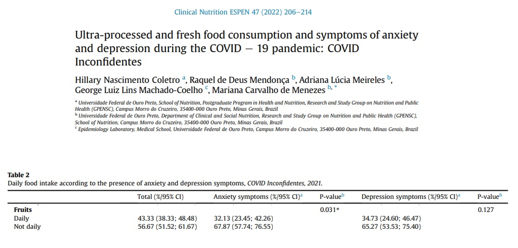